# Clase 7: Modelos lineales Generalizados: Binomial

Un modelo lineal general (GLM) con una distribución binomial se utiliza para modelar datos de respuesta binaria, es decir, datos que tienen solo dos posibles resultados, como sí/no, verdadero/falso o exitoso/fracasado. La distribución binomial se basa en la ley de Bernoulli, que describe el comportamiento de una secuencia de eventos independientes y binarios.

### Contenido

#### Base de datos

Para esta clase utilizaremos una base de datos de pumpkinsedd fish (*Lepornis gibbosus*), algunos individuos tienen un conspicuo punto rojo sobre su operculum que ha sido asociado con el comportamiento de dominancia. Zieba *et al*. (2018) investigo la funcion de este punto rojo en poblaciones de pumpkinseed colectados a lo largo de Europa donde la especie es invasiva.

La base de datos colectada por Zieba *et al*. (2018) incluye individuos con estrategias de aparamiento (female, male territoeial, male sneaker), longitud en mm, peso en gramos, y presencia del punto rojo. Sexo y estrategia de apareamiento fueron asignadas por disseccion de las gonodas. Presencia del punto rojo es la variable respuesta, y las demas variables son covariables.

Para cargar la base de datos utilizaremos el siguiente comando

```r
pkin <- read.table(file = "https://www.dropbox.com/s/xq2dojah9k0kftu/pumpkinseed.txt?dl=1",
                   header= TRUE, dec = ".", stringsAsFactors = TRUE)
```

Empezaremos con una ligera ispeccion de los datos

```r
str(pkin)
```

```
## 'data.frame':    900 obs. of  6 variables:
##  $ pop   : Factor w/ 14 levels "6T","BF","BP",..: 1 1 1 1 1 1 1 1 1 1 ...
##  $ sex   : Factor w/ 2 levels "F","M": 2 2 1 1 1 2 2 1 2 1 ...
##  $ wt    : num  6.3 8.4 6.9 8.4 9 10.1 10.7 12.4 10.6 10.9 ...
##  $ sl    : num  60.2 64.6 64.8 66.3 70.5 71.1 73.3 74.2 74.2 74.4 ...
##  $ tactic: Factor w/ 3 levels "fem","sneak",..: 3 3 1 1 1 3 3 1 3 1 ...
##  $ spot  : int  0 0 0 0 0 0 0 0 0 0 ...
```

La base de datos comprende 900 observaciones con 6 variables. Cada filarepresenta un individuo de pumpkinseed collectado de diferente poblaciones.

- pop: Poblacion
- sex: sex
- tactic: sistema de apareamiento
- wt: peso del pez
- sl: longitud
- spot: presencia del punto rojo

#### Modelos candidatos

Para construir un GLM con una distribución binomial en R, puede utilizar la función “glm()” y especificar la familia “binomial” en el argumento “family”.

```r
ModelosCan <- list("fit1_pkin" = glm(spot ~ pop, family = binomial(link = "logit"), data = pkin),
"fit2_pkin" = glm(spot ~ sex, family = binomial(link = "logit"), data = pkin),
"fit3_pkin" = glm(spot ~ tactic, family = binomial(link = "logit"), data = pkin),
"fit4_pkin" = glm(spot ~ wt, family = binomial(link = "logit"), data = pkin),
"fit5_pkin" = glm(spot ~ sl, family = binomial(link = "logit"), data = pkin),
"fit6_pkin" = glm(spot ~ pop + sex + tactic, family = binomial(link = "logit"), data = pkin),
"fit7_pkin" = glm(spot ~ sex + wt + sl, family = binomial(link = "logit"), data = pkin),
"fit8_pkin" = glm(spot ~ tactic + wt + sl, family = binomial(link = "logit"), data = pkin),
"fit9_pkin" = glm(spot ~ pop:sex, family = binomial(link = "logit"), data = pkin),
"fit10_pkin" = glm(spot ~ pop:tactic, family = binomial(link = "logit"), data = pkin),
"fit10_pkin" = glm(spot ~ wt*sl, family = binomial(link = "logit"), data = pkin))
```

#### Sellecion del modelo

```r
library(AICcmodavg)

aictab(ModelosCan)
```

```
##
## Model selection based on AICc:
##
##             K    AICc Delta_AICc AICcWt Cum.Wt      LL
## fit6_pkin  16  824.02       0.00   0.99   0.99 -395.70
## fit10_pkin 38  833.50       9.48   0.01   1.00 -377.03
## fit9_pkin  27  845.85      21.82   0.00   1.00 -395.06
## fit7_pkin   4  863.24      39.21   0.00   1.00 -427.60
## fit8_pkin   5  863.94      39.92   0.00   1.00 -426.94
## fit1_pkin  14  959.38     135.35   0.00   1.00 -465.45
## fit10_pkin  4 1003.12     179.09   0.00   1.00 -497.54
## fit5_pkin   2 1028.67     204.65   0.00   1.00 -512.33
## fit3_pkin   3 1037.90     213.88   0.00   1.00 -515.94
## fit2_pkin   2 1045.45     221.42   0.00   1.00 -520.72
## fit4_pkin   2 1049.97     225.95   0.00   1.00 -522.98
```

#### Validacion del modelo

Usaremos el paquete `DHARma`

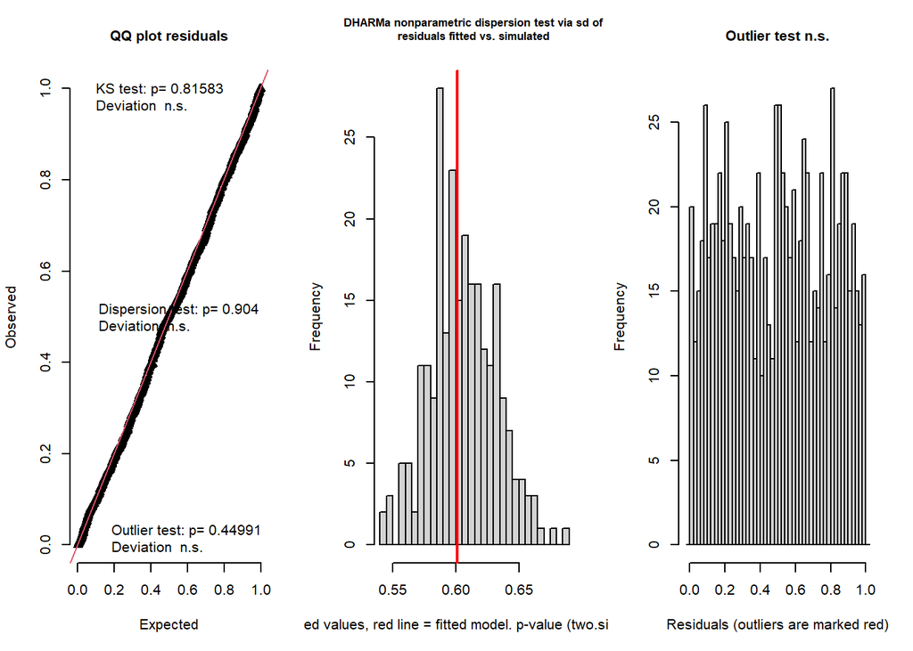

```
## $uniformity
##
##  Asymptotic one-sample Kolmogorov-Smirnov test
##
## data:  simulationOutput$scaledResiduals
## D = 0.021144, p-value = 0.8158
## alternative hypothesis: two-sided
##
##
## $dispersion
##
##  DHARMa nonparametric dispersion test via sd of residuals fitted vs.
##  simulated
##
## data:  simulationOutput
## dispersion = 0.99257, p-value = 0.904
## alternative hypothesis: two.sided
##
##
## $outliers
##
##  DHARMa outlier test based on exact binomial test with approximate
##  expectations
##
## data:  simulationOutput
## outliers at both margin(s) = 9, observations = 900, p-value = 0.4499
## alternative hypothesis: true probability of success is not equal to 0.007968127
## 95 percent confidence interval:
##  0.004582545 0.018897910
## sample estimates:
## frequency of outliers (expected: 0.00796812749003984 )
##                                                   0.01
```

```
## $uniformity
##
##  Asymptotic one-sample Kolmogorov-Smirnov test
##
## data:  simulationOutput$scaledResiduals
## D = 0.021144, p-value = 0.8158
## alternative hypothesis: two-sided
##
##
## $dispersion
##
##  DHARMa nonparametric dispersion test via sd of residuals fitted vs.
##  simulated
##
## data:  simulationOutput
## dispersion = 0.99257, p-value = 0.904
## alternative hypothesis: two.sided
##
##
## $outliers
##
##  DHARMa outlier test based on exact binomial test with approximate
##  expectations
##
## data:  simulationOutput
## outliers at both margin(s) = 9, observations = 900, p-value = 0.4499
## alternative hypothesis: true probability of success is not equal to 0.007968127
## 95 percent confidence interval:
##  0.004582545 0.018897910
## sample estimates:
## frequency of outliers (expected: 0.00796812749003984 )
##                                                   0.01
```

```r
library(DHARMa)
testResiduals(ModelosCan$fit6_pkin)
```

La distancia de Cook es una medida de la influencia de un punto de datos en un modelo de regresión. Un punto de datos con una distancia de Cook alta puede tener un gran impacto en el modelo y puede ser un indicador de que el modelo no se ajusta adecuadamente a los datos.

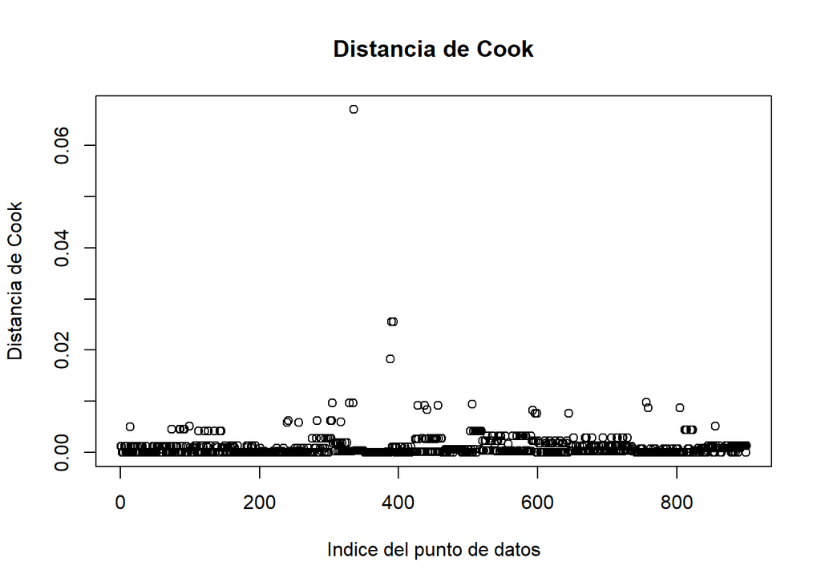

```r
plot(cooks.distance(ModelosCan$fit6_pkin),
     main="Distancia de Cook",
     xlab="Indice del punto de datos",
     ylab="Distancia de Cook")
```

#### Interpretacion del Modelo

```r
summary(ModelosCan$fit6_pkin)
```

```
##
## Call:
## glm(formula = spot ~ pop + sex + tactic, family = binomial(link = "logit"),
##     data = pkin)
##
## Deviance Residuals:
##     Min       1Q   Median       3Q      Max
## -2.7220  -0.7294  -0.2842   0.6650   2.5617
##
## Coefficients: (1 not defined because of singularities)
##             Estimate Std. Error z value Pr(>|z|)
## (Intercept)  -2.2890     0.2968  -7.713 1.23e-14 ***
## popBF         2.1654     0.3705   5.845 5.07e-09 ***
## popBP        -0.6135     0.4019  -1.527 0.126836
## popBROD       1.7257     0.5153   3.349 0.000811 ***
## popBSR       -0.3501     1.0768  -0.325 0.745103
## popBSS      -16.3039   626.6996  -0.026 0.979245
## popCKAN       3.6854     0.6867   5.367 8.00e-08 ***
## popCKL       -0.0202     0.4706  -0.043 0.965760
## popCS        -0.9537     0.4425  -2.155 0.031133 *
## popFL         1.1895     0.3797   3.132 0.001734 **
## popHN         2.3953     0.4414   5.427 5.74e-08 ***
## popHS         1.1008     0.3684   2.988 0.002808 **
## popLC        -0.9004     0.4453  -2.022 0.043146 *
## popUC        -0.2105     0.3713  -0.567 0.570630
## sexM          2.2832     0.2132  10.707  < 2e-16 ***
## tacticsneak  -1.0151     0.2913  -3.484 0.000493 ***
## tacticterr        NA         NA      NA       NA
## ---
## Signif. codes:  0 '***' 0.001 '**' 0.01 '*' 0.05 '.' 0.1 ' ' 1
##
## (Dispersion parameter for binomial family taken to be 1)
##
##     Null deviance: 1199.16  on 899  degrees of freedom
## Residual deviance:  791.41  on 884  degrees of freedom
## AIC: 823.41
##
## Number of Fisher Scoring iterations: 16
```

#### Graficos

##### Categoricos

- **Sex**

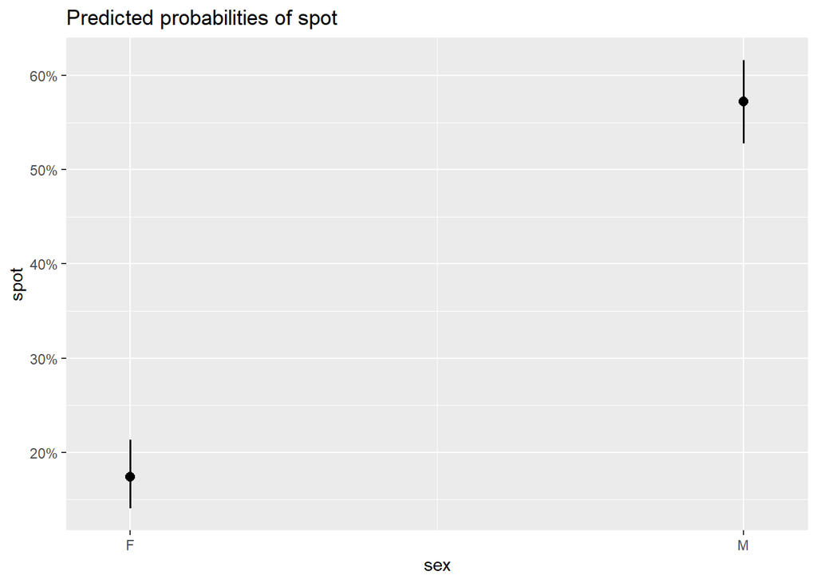

```r
library(ggplot2)
library(sjPlot)

plot_model(ModelosCan$fit2_pkin, "pre")
```

```r
library(effects)
```

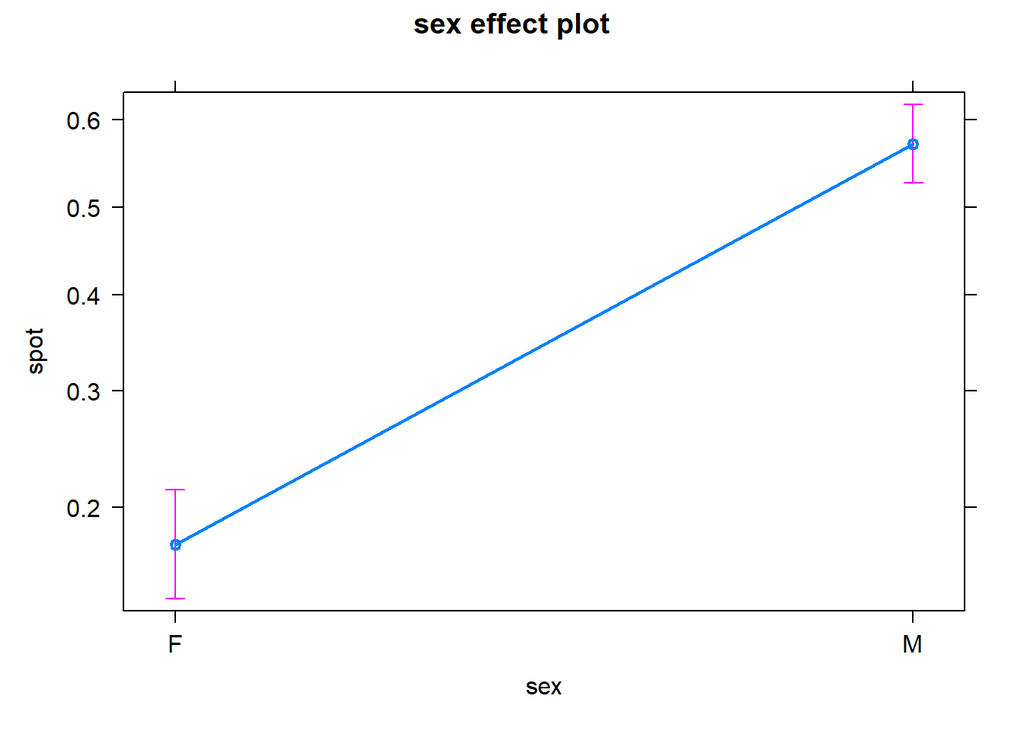

```r
eff <- effect("sex", ModelosCan$fit2_pkin)
plot(eff)
```

- **Tactic**

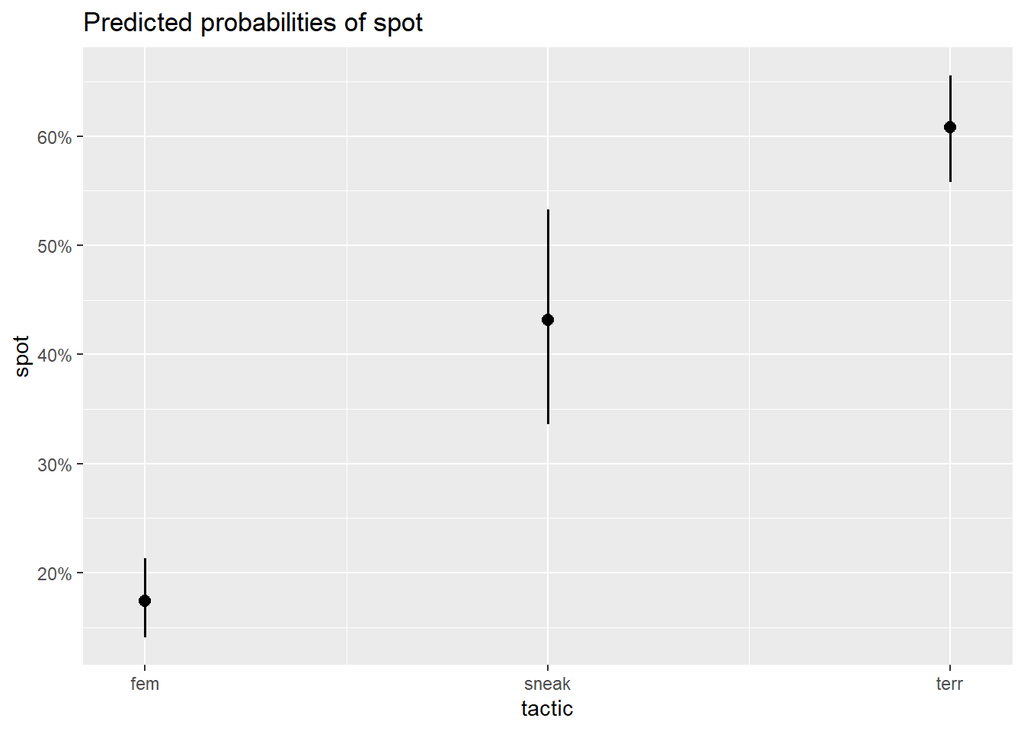

```r
plot_model(ModelosCan$fit3_pkin, "pre")
```

- **Poblacion**

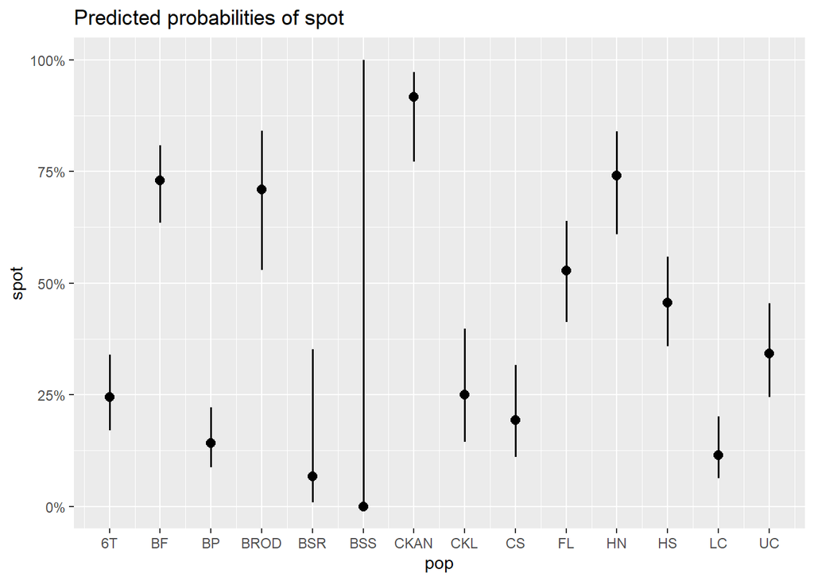

```r
plot_model(ModelosCan$fit1_pkin, "pre")
```

##### Continuos

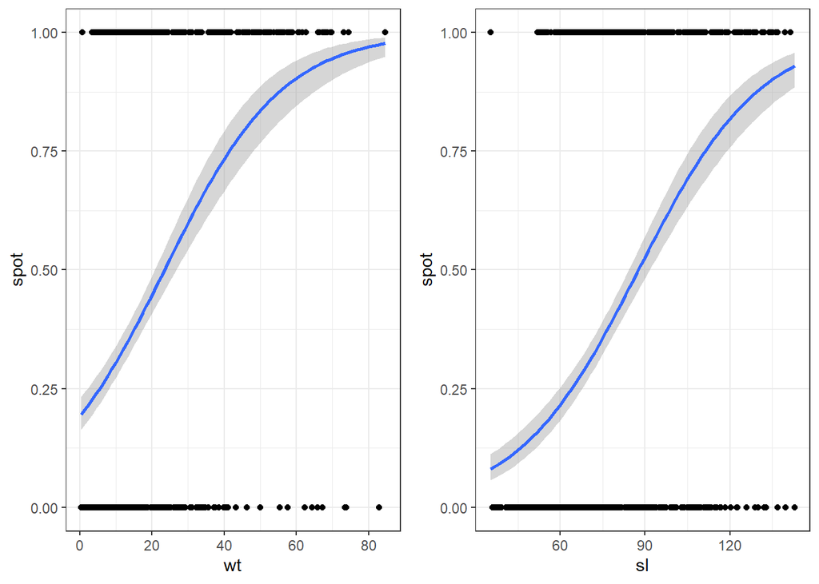

```r
wt <- ggplot(data= pkin, aes(x= wt , y= spot)) +
  stat_smooth(method = "glm", method.args = list(family = "binomial"))+
  geom_point()+
  theme_bw()

sl <- ggplot(data= pkin, aes(x= sl , y= spot)) +
  stat_smooth(method = "glm", method.args = list(family = "binomial"))+
  geom_point()+
  theme_bw()

cowplot::plot_grid(wt, sl, nrow = 1, ncol = 2)
```

##### Interaccion

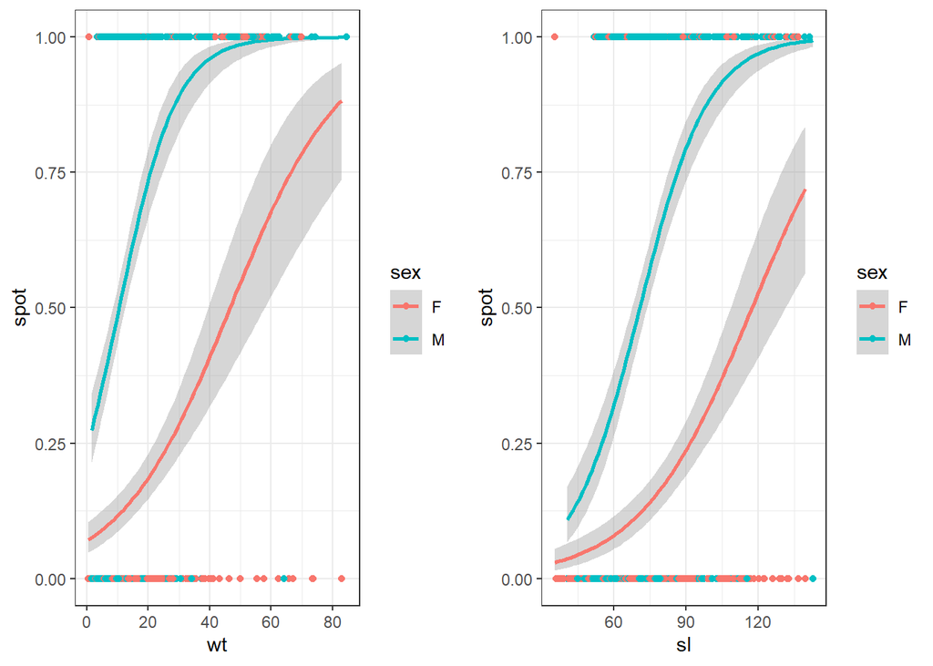

```r
wt_sex <- ggplot(data= pkin, aes(x= wt , y= spot, color = sex)) +
  stat_smooth(method = "glm", method.args = list(family = "binomial"))+
  geom_point()+
  theme_bw()

sl_sex <- ggplot(data= pkin, aes(x= sl , y= spot, color = sex)) +
  stat_smooth(method = "glm", method.args = list(family = "binomial"))+
  geom_point()+
  theme_bw()

cowplot::plot_grid(wt_sex, sl_sex, nrow = 1, ncol = 2)
```